# Predicting Barbell Lifts

Benny

13 februari 2016

## Background

Using devices such as Jawbone Up, Nike FuelBand, and Fitbit it is now possible to collect a large amount of data about personal activity relatively inexpensively. These type of devices are part of the quantified self movement – a group of enthusiasts who take measurements about themselves regularly to improve their health, to find patterns in their behavior, or because they are tech geeks.  
**In this project, the goal is to use such device data from accelerometers on the belt, forearm, arm, and dumbell of 6 participants and predict if they lift a barbell correctly**. A model is trained with help from device data where the participants lift a barbell correctly and incorrectly in 5 different ways.  
More information is available from the website here: http://groupware.les.inf.puc-rio.br/har (see the section on the Weight Lifting Exercise Dataset).

## Reducing the training set features

To do a good prediction it is important to know the input variables used in the test set. Therefore an evaluation of the testset is done. The test set contains some 157 features as input. Looking through the features it can be seen that the there are some that only contain *NA*s or are empty. This means that these columns will not give any information in the predictions.  
So, model building can be done excluding these columns from the training set.

Since some of the features in the training set is not used at all in the validation set (contains only NAs or are empty). Also, since it is belived that the name of the person should not be input to the model, this feature is also removed.

This means that the trainingset is reduced from **160** features to some **53**  
The columns that can be *excluded* from the training and test set are:

|  | Columns.to.exclude.from.training |
| --- | --- |
| 1 | kurtosis_roll_belt |
| 2 | kurtosis_picth_belt |
| 3 | kurtosis_yaw_belt |
| 4 | skewness_roll_belt |
| 5 | skewness_roll_belt.1 |
| 6 | skewness_yaw_belt |
| 7 | max_roll_belt |
| 8 | max_picth_belt |
| 9 | max_yaw_belt |
| 10 | min_roll_belt |
| 11 | min_pitch_belt |
| 12 | min_yaw_belt |
| 13 | amplitude_roll_belt |
| 14 | amplitude_pitch_belt |
| 15 | amplitude_yaw_belt |
| 16 | var_total_accel_belt |
| 17 | avg_roll_belt |
| 18 | stddev_roll_belt |
| 19 | var_roll_belt |
| 20 | avg_pitch_belt |
| 21 | stddev_pitch_belt |
| 22 | var_pitch_belt |
| 23 | avg_yaw_belt |
| 24 | stddev_yaw_belt |
| 25 | var_yaw_belt |
| 26 | var_accel_arm |
| 27 | avg_roll_arm |
| 28 | stddev_roll_arm |
| 29 | var_roll_arm |
| 30 | avg_pitch_arm |

[output cut: 77 more lines]

## Training a model

To build a model that can predict if the user lifts the barbell in a correct way, the trainingdata is divided into a training and a testset. 70% of the samples are used to train the model and 30% is used to validate it. In our case this resulted in some 13737 training samples and 5885 validation samples.  
The algorithm used in this case is Random Forest. This is a good classifier when input varibales could be dependent of each other in a complex way. Also, it is usefull when target variable is a categorical.

It was decides to grow 50 trees in the modell after looking at the error in prediction on each of the class vaiables versus number of trees grown. The error curves seams to levarage out after some 50 trees.  
The in sample error of the model is 0.8 %.

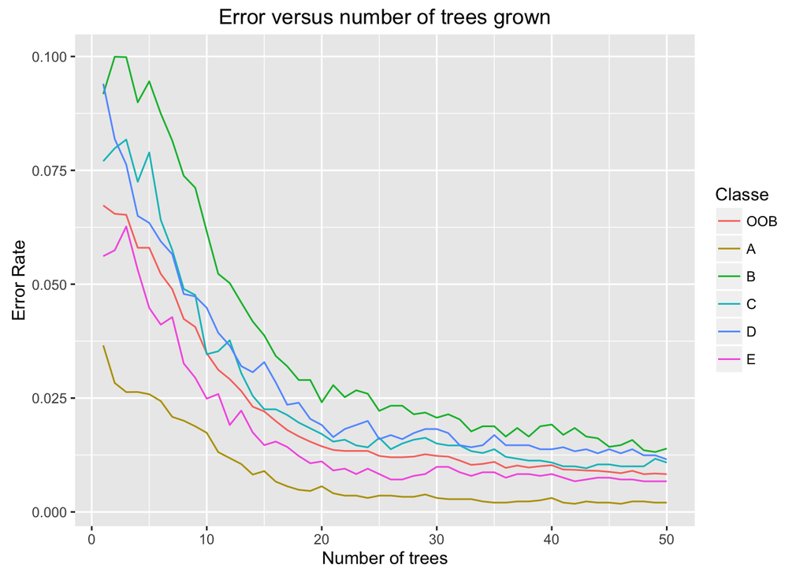

Below is the cross validation matrix. It can be seen in the confusion matrix that the prediction is rater good.

|  | A | B | C | D | E |
| --- | --- | --- | --- | --- | --- |
| A | 1672 | 11 | 0 | 0 | 0 |
| B | 1 | 1127 | 1 | 1 | 0 |
| C | 0 | 1 | 1021 | 17 | 2 |
| D | 0 | 0 | 4 | 941 | 4 |
| E | 1 | 0 | 0 | 5 | 1076 |

The out of sample error rate from the confusion matrix is 0.82%.

## Predicting the testset

Below is a table that contains the prediction on the tests set.

| number | Prediction |
| --- | --- |
| 1 | B |
| 2 | A |
| 3 | B |
| 4 | A |
| 5 | A |
| 6 | E |
| 7 | D |
| 8 | B |
| 9 | A |
| 10 | A |
| 11 | B |
| 12 | C |
| 13 | B |
| 14 | A |
| 15 | E |
| 16 | E |
| 17 | A |
| 18 | B |
| 19 | B |
| 20 | B |